# Visualizing Louisville, Kentucky

Nat Berry

| state | county | cbsa | lon | lat | population | hh_income_q1 | hh_income_q2 | hh_income_q3 | hh_income_q4 | hh_income_q5 | hh_income_top_5 | hh_gini | median_rent | sex_male | sex_female | age_00_17 | age_18_24 | age_25_59 | age_60_plus | race_white | race_black | race_ntvam | race_asian | race_pacif | race_other | race_multi | born_same_st | born_other_ne | born_other_midwest | … |
| --- | --- | --- | --- | --- | --- | --- | --- | --- | --- | --- | --- | --- | --- | --- | --- | --- | --- | --- | --- | --- | --- | --- | --- | --- | --- | --- | --- | --- | --- | --- |
| Indiana | Floyd County | Louisville/Jefferson County, KY-IN | -85.79874 | 38.29265 | 1711 | 7894 | 20591 | 36548 | 57726 | 109676 | 139245 | 0.4379 | 706 | 41.15 | 58.85 | 31.21 | 6.72 | 52.19 | 9.88 | 80.19 | 10.70 | 1.17 | 0.00 | 0.00 | 4.09 | 3.86 | 50.50 | 4.97 | 4.50 | … |
| Indiana | Clark County | Louisville/Jefferson County, KY-IN | -85.74357 | 38.27329 | 1255 | 9490 | 22047 | 45787 | 75461 | 161407 | 310717 | 0.4960 | 655 | 48.61 | 51.39 | 8.69 | 18.17 | 51.63 | 21.51 | 85.10 | 14.26 | 0.00 | 0.00 | 0.00 | 0.00 | 0.64 | 50.58 | 6.22 | 4.23 | … |
| Indiana | Clark County | Louisville/Jefferson County, KY-IN | -85.73499 | 38.31091 | 4403 | 22764 | 43482 | 60651 | 86696 | 196744 | 407749 | 0.4224 | 946 | 47.44 | 52.56 | 19.17 | 7.86 | 43.33 | 29.64 | 81.63 | 7.99 | 0.00 | 4.88 | 0.00 | 0.82 | 4.68 | 45.97 | 2.30 | 7.62 | … |
| Indiana | Floyd County | Louisville/Jefferson County, KY-IN | -85.81133 | 38.28937 | 2446 | 5790 | 17182 | 29966 | 56061 | 176477 | 423354 | 0.5974 | 590 | 51.96 | 48.04 | 14.23 | 10.18 | 60.18 | 15.41 | 84.01 | 9.04 | 0.00 | 1.76 | 0.00 | 2.78 | 2.41 | 51.59 | 3.27 | 5.57 | … |
| Indiana | Harrison County | Louisville/Jefferson County, KY-IN | -86.02809 | 38.19171 | 5702 | 19382 | 43296 | 61499 | 88815 | 158524 | 230460 | 0.3716 | 902 | 46.21 | 53.79 | 22.94 | 6.47 | 48.98 | 21.61 | 95.62 | 0.30 | 0.00 | 2.89 | 0.00 | 0.33 | 0.86 | 58.95 | 0.58 | 2.52 | … |
| Indiana | Clark County | Louisville/Jefferson County, KY-IN | -85.71070 | 38.28952 | 2813 | 14953 | 37655 | 55682 | 83841 | 183291 | 351331 | 0.4448 | 847 | 47.60 | 52.40 | 16.67 | 8.39 | 45.75 | 29.19 | 80.84 | 13.79 | 0.00 | 0.00 | 0.00 | 0.00 | 5.37 | 43.82 | 3.31 | 10.96 | … |
| Indiana | Floyd County | Louisville/Jefferson County, KY-IN | -85.80515 | 38.30181 | 3483 | 11086 | 30099 | 49354 | 73321 | 105790 | 144148 | 0.3658 | 831 | 49.47 | 50.53 | 20.70 | 7.44 | 51.74 | 20.13 | 87.60 | 1.98 | 0.49 | 1.26 | 0.00 | 1.72 | 6.95 | 48.72 | 1.70 | 5.40 | … |
| Indiana | Clark County | Louisville/Jefferson County, KY-IN | -85.68265 | 38.42574 | 4141 | 10112 | 25839 | 41092 | 68017 | 131794 | 192745 | 0.4384 | 579 | 46.37 | 53.63 | 25.02 | 10.14 | 52.28 | 12.56 | 85.41 | 3.67 | 0.00 | 0.72 | 0.00 | 6.86 | 3.33 | 52.86 | 1.66 | 5.02 | … |
| Indiana | Clark County | Louisville/Jefferson County, KY-IN | -85.75904 | 38.30713 | 2984 | 11766 | 28220 | 40778 | 54749 | 86709 | 107896 | 0.3347 | 746 | 49.46 | 50.54 | 14.91 | 14.18 | 56.97 | 13.94 | 84.28 | 10.12 | 0.00 | 0.00 | 0.00 | 2.38 | 3.22 | 44.52 | 2.37 | 6.76 | … |
| Indiana | Clark County | Louisville/Jefferson County, KY-IN | -85.78722 | 38.31554 | 1728 | 14832 | 34125 | 55969 | 81487 | 142769 | 202546 | 0.3905 | 723 | 48.96 | 51.04 | 16.78 | 9.72 | 42.59 | 30.90 | 98.67 | 0.87 | 0.00 | 0.00 | 0.00 | 0.00 | 0.46 | 53.07 | 1.18 | 6.86 | … |

[output cut: 289 more lines]

| max_race_category | lon_mean | lat_mean | population_mean | hh_income_q1_mean | hh_income_q2_mean | hh_income_q3_mean | hh_income_q4_mean | hh_income_q5_mean | hh_income_top_5_mean | hh_gini_mean | median_rent_mean | sex_male_mean | sex_female_mean | age_00_17_mean | age_18_24_mean | age_25_59_mean | age_60_plus_mean | race_white_mean | race_black_mean | race_ntvam_mean | race_asian_mean | race_pacif_mean | race_other_mean | race_multi_mean | born_same_st_mean | born_other_ne_mean | born_other_midwest_mean | born_other_south_mean | born_other_west_mean | … |
| --- | --- | --- | --- | --- | --- | --- | --- | --- | --- | --- | --- | --- | --- | --- | --- | --- | --- | --- | --- | --- | --- | --- | --- | --- | --- | --- | --- | --- | --- | --- |
| race_black | -85.79027 | 38.22918 | 3458.903 | 6296.516 | 15716.42 | 26621.71 | 43245.65 | 85907.71 | 130269.3 | 0.4503710 | 647.7419 | 45.79290 | 54.20710 | 27.35000 | 10.620645 | 44.99355 | 17.03516 | 19.73645 | 76.178710 | 0.05258065 | 0.5119355 | 0.04387097 | 0.4480645 | 3.029677 | 81.73613 | 1.540000 | 6.055161 | 9.082903 | 1.585484 | … |
| race_white | -85.67371 | 38.24653 | 4288.146 | 16153.112 | 37043.78 | 57718.69 | 85025.94 | 164745.70 | 267504.4 | 0.4077541 | 848.9216 | 49.14657 | 50.85343 | 22.17761 | 8.562649 | 48.27623 | 20.98317 | 85.39843 | 9.183769 | 0.17787313 | 1.7604851 | 0.04123134 | 0.8629104 | 2.575448 | 69.59623 | 3.137201 | 10.728507 | 13.970970 | 2.567276 | … |

## Introduction

Last summer I worked in the Digital Scholarship Lab at the University of Richmond. Specifically, I worked on the Mapping Inequality project. The purpose of the Mapping Inequality project was to digitize the maps created by the Home Owners Loan Corporation during the New Deal. These maps effectively determined whether people in various neighborhoods in cities across the United States could recieve loans backed by the government in order to buy homes. Often those decisions and the maps that represent them are based heavily on the racial makeup of the communities. Meaning more diverse communities were consistently considered ineleigible for loans. The purpose of this analysis is to understand the lasting effects of HOLC’s practices in Louisville. In order to do that I am analyzing the Louisville/Jefferson County, KY-IN census tract data focusing specifically on patterns of racial and socioeconomic makeup of each community.

## Analysis

I began this analysis by seeing if the racially segregated communities created by the HOLC were intact today. In order to do this, I needed to gain a simple understanding of the racial makeup of each community. Graph 1 shows the dominant racial group within each census tract. As one can clearly see, a majority of the census tracts in the Louisville metro area are predominantly white. However, there is a section in the southwest corner of Louisville that is predominantly black. This concentration of black citizens almost perfectly overlays the areas that were determined ‘hazardous’ or ‘definitely declining’ by the HOLC. Most of these neighborhoods were given such a designation because of their racial makeup, and as the map below shows, that racial makeup has remained.

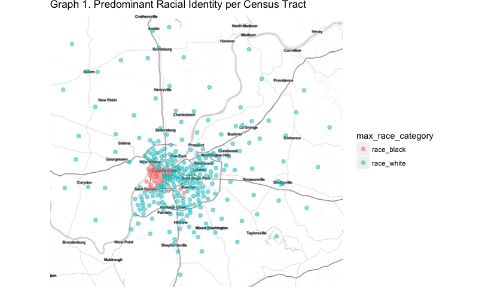

But where people of different racial groups live is only part of the story. I also want to better understand the socioeconomic differences between those communities. In order to do this, I created Graph 2 which shows the average household income for each tract compared to the percentage of residents in that tract that identified as white.

[figure not shown]

This data makes it clear that there are significant variations in the wealth that predominantly black communities have accumulated in comparison to predominantly white communities. However, I wanted to understand the practical impacts that this racial wealth gap has on various communities in Louisville. In order to better understand those practical impacts, I created Graph 3.

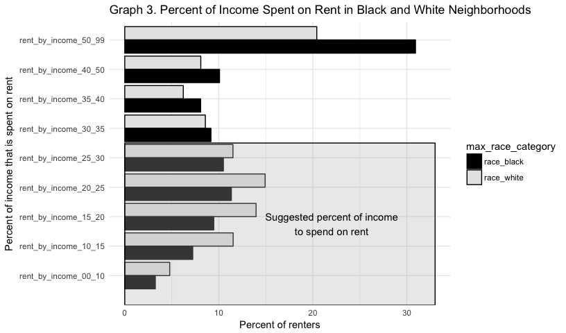

Graph 3 compares the percentage of a household’s income that is spent on rent in both predominantly white and predominantly black neighborhoods. Though there is no universally applicable rule determining how much a household should spend on rent, many economists agree that a household should not spend more than 30% of their income on rent. As this graph demonstrates, a greater proportion of renters in predominantly white neighborhoods spend less than 30% of their income on rent compared to renters in predominantly black neighborhoods. This relationship is flipped when analyzing renters who spend over the recommended 30% of their income on rent. Renters in predominantly black neighborhoods are far more likely to spend upwards of 30% of their income on rent when compared to renters in white neighborhoods. Nearly 1 in 3 renters in predominantly black neighborhoods are forced to spend over half of their income on rent, whereas only 1 in 5 renters in predominantly white neighborhoods are forced into similar situations.

## Conclusion

Together, these three graphs illustrate a chilling story of the continued impact that the HOLC and its racist approach to home loans is having on Louisville, Kentucky and the surrounding area. The original maps published by HOLC determined areas that had a significant black or minority population as ineligible for federally backed home loans. As Graph 1 shows those racially segregated neighborhoods exist today. By making it nearly impossible for predominantly black communities to purchase a home-the most common way of accumulating wealth in the United States-the HOLC handicapped those communities and the households that form them in their efforts to accumulate wealth. As Graph 2 demonstrates the wealth disparities between predominantly black and predominantly white communities is not a theoretical concept, but a lived reality in Louisville. There are many explanations for why America has such a large racial wealth gap, but all explanations must at least entertain the idea that the HOLC contributed to it in part. And finally, Graph 3 illustrates the practical effect that the racial wealth gap has on an individual level. Households in predominantly black neighborhoods are forced to spend far greater amounts of their income on basic necessities on rent compared to renters in white neighborhoods. This means renters in black neighborhoods are left with far less money to spend on other expenses. It is impossible to identify one singular cause of economic inequality that persists between communities of color and white communities, however, this analysis, coupled with the work done by Mapping Inequality, suggest that the HOLC was and is a major contributor to that inequality

## References

Robert K. Nelson, LaDale Winling, Richard Marciano, Nathan Connolly, et al., “Mapping Inequality,” American Panorama, ed. Robert K. Nelson and Edward L. Ayers, accessed March 5, 2018, https://dsl.richmond.edu/panorama/redlining/#loc=4/36.71/-96.93&opacity=0.8